# Data Mining Week 2: Regression

- Linear Regression
- Multiple Linear Regression
- ANOVA
- LASSO
- Ridge Regression
- Evaluation Methods

```python
# Get working directory
import os
os.getcwd()
```

```
'/Users/matthewberezo'
```

```python
# Read in csv file for World War 2 weather conditions that is stored in path:
import pandas as pd
pd.set_option('display.max_columns', None)
pd.set_option('display.max_rows', None)
ww2_weath = pd.read_csv('/Users/matthewberezo/Documents/Summary_of_Weather.csv')
```

```python
# Preview the dataset with the .head() function:
# Variable descriptions and definitions can be found at: https://www.kaggle.com/smid80/weatherww2/data
ww2_weath.head()
```

|  | STA | Date | Precip | WindGustSpd | MaxTemp | MinTemp | MeanTemp | Snowfall | PoorWeather | YR | MO | DA | PRCP | DR | SPD | MAX | MIN | MEA | SNF | SND | FT | FB | FTI | ITH | PGT | TSHDSBRSGF | SD3 | RHX | RHN | … |
| --- | --- | --- | --- | --- | --- | --- | --- | --- | --- | --- | --- | --- | --- | --- | --- | --- | --- | --- | --- | --- | --- | --- | --- | --- | --- | --- | --- | --- | --- | --- |
| 0 | 10001 | 1942-7-1 | 1.016 | NaN | 25.555556 | 22.222222 | 23.888889 | 0 | NaN | 42 | 7 | 1 | 0.04 | NaN | NaN | 78.0 | 72.0 | 75.0 | 0 | NaN | NaN | NaN | NaN | NaN | NaN | NaN | NaN | NaN | NaN | … |
| 1 | 10001 | 1942-7-2 | 0 | NaN | 28.888889 | 21.666667 | 25.555556 | 0 | NaN | 42 | 7 | 2 | 0 | NaN | NaN | 84.0 | 71.0 | 78.0 | 0 | NaN | NaN | NaN | NaN | NaN | NaN | NaN | NaN | NaN | NaN | … |
| 2 | 10001 | 1942-7-3 | 2.54 | NaN | 26.111111 | 22.222222 | 24.444444 | 0 | NaN | 42 | 7 | 3 | 0.1 | NaN | NaN | 79.0 | 72.0 | 76.0 | 0 | NaN | NaN | NaN | NaN | NaN | NaN | NaN | NaN | NaN | NaN | … |
| 3 | 10001 | 1942-7-4 | 2.54 | NaN | 26.666667 | 22.222222 | 24.444444 | 0 | NaN | 42 | 7 | 4 | 0.1 | NaN | NaN | 80.0 | 72.0 | 76.0 | 0 | NaN | NaN | NaN | NaN | NaN | NaN | NaN | NaN | NaN | NaN | … |
| 4 | 10001 | 1942-7-5 | 0 | NaN | 26.666667 | 21.666667 | 24.444444 | 0 | NaN | 42 | 7 | 5 | 0 | NaN | NaN | 80.0 | 71.0 | 76.0 | 0 | NaN | NaN | NaN | NaN | NaN | NaN | NaN | NaN | NaN | NaN | … |

```python
# We can also get a discription of the dataframe:
ww2_weath.describe()
```

|  | STA | WindGustSpd | MaxTemp | MinTemp | MeanTemp | YR | MO | DA | DR | SPD | MAX | MIN | MEA | SND | FT | FB | FTI | ITH | PGT | SD3 | RHX | RHN | RVG | WTE |
| --- | --- | --- | --- | --- | --- | --- | --- | --- | --- | --- | --- | --- | --- | --- | --- | --- | --- | --- | --- | --- | --- | --- | --- | --- |
| count | 119040.000000 | 532.000000 | 119040.000000 | 119040.000000 | 119040.000000 | 119040.000000 | 119040.000000 | 119040.000000 | 533.000000 | 532.000000 | 118566.000000 | 118572.000000 | 118542.000000 | 5563.0 | 0.0 | 0.0 | 0.0 | 0.0 | 525.000000 | 0.0 | 0.0 | 0.0 | 0.0 | 0.0 |
| mean | 29659.435795 | 37.774534 | 27.045111 | 17.789511 | 22.411631 | 43.805284 | 6.726016 | 15.797530 | 26.998124 | 20.396617 | 81.003745 | 64.273808 | 72.644843 | 0.0 | NaN | NaN | NaN | NaN | 12.085333 | NaN | NaN | NaN | NaN | NaN |
| std | 20953.209402 | 10.297808 | 8.717817 | 8.334572 | 8.297982 | 1.136718 | 3.425561 | 8.794541 | 15.221732 | 5.560371 | 14.869361 | 14.481498 | 14.211082 | 0.0 | NaN | NaN | NaN | NaN | 5.731328 | NaN | NaN | NaN | NaN | NaN |
| min | 10001.000000 | 18.520000 | -33.333333 | -38.333333 | -35.555556 | 40.000000 | 1.000000 | 1.000000 | 2.000000 | 10.000000 | -28.000000 | -37.000000 | -32.000000 | 0.0 | NaN | NaN | NaN | NaN | 0.000000 | NaN | NaN | NaN | NaN | NaN |
| 25% | 11801.000000 | 29.632000 | 25.555556 | 15.000000 | 20.555556 | 43.000000 | 4.000000 | 8.000000 | 11.000000 | 16.000000 | 78.000000 | 59.000000 | 69.000000 | 0.0 | NaN | NaN | NaN | NaN | 8.500000 | NaN | NaN | NaN | NaN | NaN |
| 50% | 22508.000000 | 37.040000 | 29.444444 | 21.111111 | 25.555556 | 44.000000 | 7.000000 | 16.000000 | 32.000000 | 20.000000 | 85.000000 | 70.000000 | 78.000000 | 0.0 | NaN | NaN | NaN | NaN | 11.600000 | NaN | NaN | NaN | NaN | NaN |
| 75% | 33501.000000 | 43.059000 | 31.666667 | 23.333333 | 27.222222 | 45.000000 | 10.000000 | 23.000000 | 34.000000 | 23.250000 | 89.000000 | 74.000000 | 81.000000 | 0.0 | NaN | NaN | NaN | NaN | 15.000000 | NaN | NaN | NaN | NaN | NaN |
| max | 82506.000000 | 75.932000 | 50.000000 | 34.444444 | 40.000000 | 45.000000 | 12.000000 | 31.000000 | 78.000000 | 41.000000 | 122.000000 | 94.000000 | 104.000000 | 0.0 | NaN | NaN | NaN | NaN | 23.900000 | NaN | NaN | NaN | NaN | NaN |

```python
# To get a description of a specific column:
ww2_weath['STA'].describe()
```

```
count    119040.000000
mean      29659.435795
std       20953.209402
min       10001.000000
25%       11801.000000
50%       22508.000000
75%       33501.000000
max       82506.000000
Name: STA, dtype: float64
```

```python
#We can also see the shape of our dataframe:
ww2_weath.shape
```

```
(119040, 31)
```

```python
# It looks like there are nulls in the dataframe.  How can we find how many nulls exist?
ww2_weath.isnull().sum(axis = 0) # gives the number of nulls in each column
```

```
STA                 0
Date                0
Precip              0
WindGustSpd    118508
MaxTemp             0
MinTemp             0
MeanTemp            0
Snowfall         1163
PoorWeather     84803
YR                  0
MO                  0
DA                  0
PRCP             1932
DR             118507
SPD            118508
MAX               474
MIN               468
MEA               498
SNF              1163
SND            113477
FT             119040
FB             119040
FTI            119040
ITH            119040
PGT            118515
TSHDSBRSGF      84803
SD3            119040
RHX            119040
RHN            119040
RVG            119040
WTE            119040
dtype: int64
```

#### Many of these columns have all null values. We should drop these columns:

```python
ww2_weath.drop(['FT'],axis=1,inplace=True)
ww2_weath.drop(['FB'],axis=1,inplace=True)
ww2_weath.drop(['FTI'],axis=1,inplace=True)
ww2_weath.drop(['ITH'],axis=1,inplace=True)
ww2_weath.drop(['SD3'],axis=1,inplace=True)
ww2_weath.drop(['RHX'],axis=1,inplace=True)
ww2_weath.drop(['RHN'],axis=1,inplace=True)
ww2_weath.drop(['RVG'],axis=1,inplace=True)
ww2_weath.drop(['WTE'],axis=1,inplace=True)
```

```python
ww2_weath.isnull().sum(axis = 1) # gives the number of nulls in each row
```

```
0          7
1          7
2          7
3          7
4          7
5          7
6          7
7          7
8          7
9          7
10         7
11         7
12         7
13         7
14         7
```

[output cut: 119026 more lines]

#### From Kaggle's variable definitions, we are able to decipher which variables are coninuous and which are strings.

#### We can convert variables that are numeric into categorical and vice versa if need be.

```python
ww2_weath.dtypes
```

```
STA              int64
Date            object
Precip          object
WindGustSpd    float64
MaxTemp        float64
MinTemp        float64
MeanTemp       float64
Snowfall        object
PoorWeather     object
YR               int64
MO               int64
DA               int64
PRCP            object
DR             float64
SPD            float64
MAX            float64
MIN            float64
MEA            float64
SNF             object
SND            float64
PGT            float64
TSHDSBRSGF      object
dtype: object
```

```python
# Let's check the unique values in the "Precip" column.  Why is this listed as a string on Kaggle?
ww2_weath.Precip.unique()
```

```
array(['1.016', '0', '2.54', 'T', '3.556', '0.508', '0.254', '1.778',
       '3.302', '0.762', '5.588', '5.08', '2.032', '25.654', '40.132',
       '19.05', '23.876', '4.064', '12.192', '2.794', '33.274', '19.304',
       '47.752', '6.35', '3.048', '8.382', '10.16', '27.178', '30.48',
       '45.212', '10.668', '15.494', '57.658', '58.166', '11.43',
       '31.242', '17.78', '26.924', '26.67', '6.604', '5.334', '4.826',
       '7.62', '8.636', '7.874', '12.446', '90.932', '13.462', '11.938',
       '5.842', '4.318', '6.096', '9.144', '4.572', '9.906', '9.652',
       '1.524', '13.97', '17.272', '33.528', '1.27', '13.716', '8.128',
       '22.352', '39.116', '36.068', '98.044', '3.81', '14.986', '78.232',
       '146.304', '14.732', '21.844', '120.904', '42.164', '23.368',
       '21.082', '44.958', '2.286', '50.038', '17.526', '51.054', '7.112',
       '25.4', '7.366', '16.256', '46.736', '8.89', '24.638', '11.684',
       '17.018', '144.78', '18.034', '50.8', '106.426', '36.576', '53.34',
       '34.798', '12.954', '26.416', '85.598', '47.498', '12.7', '11.176',
       '59.182', '33.782', '40.894', '28.194', '24.892', '14.478',
       '71.628', '102.108', '31.496', '36.322', '37.846', '35.56',
       '31.75', '49.022', '69.85', '36.83', '19.558', '127.508', '64.77',
       '105.156', '16.002', '75.184', '143.51', '60.96', '68.58', '55.88',
       '23.622', '126.238', '70.358', '6.858', '16.764', '24.13',
       '52.832', '25.146', '74.676', '16.51', '65.024', '51.816',
       '13.208', '30.226', '29.972', '215.9', '21.336', '76.962',
       '29.464', '9.398', '15.748', '45.974', '41.148', '48.514', '33.02',
       '10.414', '18.796', '14.224', '68.326', '80.264', '70.866',
       '35.814', '22.86', '30.988', '20.828', '34.036', '20.066',
       '27.432', '62.23', '37.338', '55.372', '73.66', '18.288',
       '114.808', '56.388', '273.558', '27.686', '111.506', '101.346',
       '120.142', '116.586', '66.294', '32.766', '55.118', '30.734',
       '46.228', '68.072', '62.484', '72.644', '203.708', '15.24',
       '61.214', '48.768', '10.922', '54.61', '81.788', '38.1', '37.592',
       '18.542', '49.784', '32.258', '94.488', '67.818', '41.402',
       '22.606', '43.434', '27.94', '61.468', '25.908', '54.102',
       '52.578', '46.99', '177.8', '28.956', '119.38', '44.45', '85.344',
       '95.758', '91.948', '38.354', '39.624', '80.01', '40.386',
       '35.306', '88.646', '65.786', '136.398', '77.978', '116.84',
       '75.438', '69.596', '42.672', '39.37', '20.574', '39.878',
       '42.926', '38.608', '155.448', '140.716', '148.336', '19.812',
       '60.706', '97.028', '57.912', '72.898', '65.532', '71.882',
       '21.59', '22.098', '34.29', '35.052', '43.18', '50.546', '20.32',
       '70.612', '67.31', '28.448', '32.004', '48.006', '76.2', '37.084',
```

[output cut: 32 more lines]

```
       '72.136', '194.564', '112.522', '134.112', '128.778', '83.312',
       '96.774', '168.656', '78.74', '117.348', '80.772', '125.222',
       '182.626', '132.588', '209.804', '116.078', '89.154', '129.54',
       '96.266', '86.36', '117.602', '83.566', '92.964', '109.982',
       '92.202', '149.352', '66.802', '122.174', '233.172', '200.406',
       '124.968', '89.916', '139.954', '184.404', '91.44', '89.662',
       '100.838', '101.6', '119.634', '98.298', '94.996', '132.842',
       '84.328', '130.556', '99.822', '109.728', '91.186', '96.52',
       '106.172', '72.39', '104.648', '238.506', '139.192', '132.334',
       '113.03', '175.006', '124.714', '150.114', '125.476', '119.888',
       '133.858', '167.386', '114.554', '115.316', '84.582', '185.166',
       '104.902', '111.252', '164.846', '118.872', '167.64', '163.322',
       '111.76', '104.14', '194.31', '140.208', '110.236', '153.162',
       '165.1', '242.316', '154.686', '105.918', '133.096', '161.036'],
      dtype=object)
```

#### We can see in the "Precip" column, the value "T" exists. If we try to conver this to a numeric field, python will fail:

#### This will be true for all string fields in the dataset

```python
ww2_weath['Precip'].astype(float)
```

[output not shown]

```python
#Let's look at WindGustSpd
ww2_weath.WindGustSpd.unique()
```

```
array([   nan, 29.632, 59.264, 50.004, 40.744, 51.856, 44.448, 57.412,
       53.708, 42.596, 62.968, 68.524, 61.116, 46.3  , 38.892, 55.56 ,
       31.484, 37.04 , 74.08 , 64.82 , 48.152, 35.188, 27.78 , 33.336,
       20.372, 22.224, 24.076, 25.928, 75.932, 66.672, 18.52 ])
```

```python
#WindGustSpd does contain nulls, which allows this column to be converted to a float
ww2_weath['WindGustSpd'] = ww2_weath['WindGustSpd'].astype(float)
```

```python
#Let's look at PRCP
ww2_weath.PRCP.unique()
```

```
array(['0.04', '0', '0.1', 'T', '0.14', '0.02', '0.01', '0.07', '0.13',
       '0.03', '0.22', '0.2', '0.08', '1.01', '1.58', '0.75', '0.94',
       '0.16', '0.48', '0.11', '1.31', '0.76', '1.88', '0.25', '0.12',
       '0.33', '0.4', '1.07', '1.2', '1.78', '0.42', '0.61', '2.27',
       '2.29', '0.45', '1.23', '0.7', '1.06', '1.05', '0.26', '0.21',
       '0.19', '0.3', '0.34', '0.31', '0.49', '3.58', '0.53', '0.47',
       '0.23', '0.17', '0.24', '0.36', '0.18', '0.39', '0.38', '0.06',
       '0.55', '0.68', '1.32', '0.05', '0.54', '0.32', '0.88', '1.54',
       '1.42', '3.86', '0.15', '0.59', '3.08', '5.76', '0.58', '0.86',
       '4.76', '1.66', '0.92', '0.83', '1.77', '0.09', nan, '1.97',
       '0.69', '2.01', '0.28', '1', '0.29', '0.64', '1.84', '0.35',
       '0.97', '0.46', '0.67', '5.7', '0.71', '2', '4.19', '1.44', '2.1',
       '1.37', '0.51', '1.04', '3.37', '1.87', '0.5', '0.44', '2.33',
       '1.33', '1.61', '1.11', '0.98', '0.57', '2.82', '4.02', '1.24',
       '1.43', '1.49', '1.4', '1.25', '1.93', '2.75', '1.45', '0.77',
       '5.02', '2.55', '4.14', '0.63', '2.96', '5.65', '2.4', '2.7',
       '2.2', '0.93', '4.97', '2.77', '0.27', '0.66', '0.95', '2.08',
       '0.99', '2.94', '0.65', '2.56', '2.04', '0.52', '1.19', '1.18',
       '8.5', '0.84', '3.03', '1.16', '0.37', '0.62', '1.81', '1.62',
       '1.91', '1.3', '0.41', '0.74', '0.56', '2.69', '3.16', '2.79',
       '1.41', '0.9', '1.22', '0.82', '1.34', '0.79', '1.08', '2.45',
       '1.47', '2.18', '2.9', '0.72', '4.52', '2.22', '10.77', '1.09',
       '4.39', '3.99', '4.73', '4.59', '2.61', '1.29', '2.17', '1.21',
       '1.82', '2.68', '2.46', '2.86', '8.02', '0.6', '2.41', '1.92',
       '0.43', '2.15', '3.22', '1.5', '1.48', '0.73', '1.96', '1.27',
       '3.72', '2.67', '1.63', '0.89', '1.71', '1.1', '2.42', '1.02',
       '2.13', '2.07', '1.85', '7', '1.14', '4.7', '1.75', '3.36', '3.77',
       '3.62', '1.51', '1.56', '3.15', '1.59', '1.39', '3.49', '2.59',
       '5.37', '3.07', '4.6', '2.97', '2.74', '1.68', '1.55', '0.81',
       '1.57', '1.69', '1.52', '6.12', '5.54', '5.84', '0.78', '2.39',
       '3.82', '2.28', '2.87', '2.58', '2.83', '0.85', '0.87', '1.35',
       '1.38', '1.7', '1.99', '0.8', '2.78', '2.65', '1.12', '1.26',
       '1.89', '3', '1.46', '1.9', '1.73', '3.02', '2.05', '2.06', '4.74',
       '3.17', '2.5', '4.96', '4.58', '1.83', '3.01', '1.36', '1.67',
       '1.15', '3.2', '0.96', '2.31', '4.26', '6.84', '1.95', '8.87',
       '8.12', '6.38', '3.43', '3.47', '4.08', '3.26', '3.69', '1.13',
       '3.9', '2.44', '2.02', '4.37', '3.7', '4.23', '0.91', '3.64',
       '2.25', '3.31', '1.6', '2.47', '1.64', '1.28', '1.98', '1.03',
       '2.12', '2.91', '2.54', '1.53', '3.34', '4.09', '1.65', '2.24',
       '3.23', '2.62', '2.37', '2.09', '2.14', '1.8', '1.17', '1.72',
```

[output cut: 13 more lines]

```
       '10.12', '12.1', '7.25', '3.44', '5.31', '8.14', '4.36', '3.13',
       '2.66', '3.19', '3.52', '6.47', '4.01', '3.55', '5.3', '2.32',
       '3.3', '4.8', '2.72', '3.61', '2.38', '4.15', '5.63', '5.43',
       '3.46', '3.5', '4.44', '3.09', '2.84', '7.66', '4.43', '5.28',
       '5.07', '3.28', '3.81', '6.64', '3.1', '4.62', '3.18', '4.93',
       '7.19', '5.22', '8.26', '4.57', '3.51', '5.1', '3.79', '3.4',
       '4.63', '3.29', '3.66', '4.33', '3.63', '5.88', '2.63', '4.81',
       '9.18', '7.89', '4.92', '3.54', '5.51', '7.26', '3.6', '3.53',
       '3.97', '4', '4.71', '3.87', '3.74', '5.23', '3.32', '5.14',
       '3.93', '4.32', '3.59', '3.8', '4.18', '2.85', '4.12', '9.39',
       '5.48', '5.21', '4.45', '6.89', '4.91', '5.91', '4.94', '4.72',
       '5.27', '6.59', '4.51', '4.54', '3.33', '7.29', '4.13', '4.38',
       '6.49', '4.68', '6.6', '6.43', '4.4', '4.1', '7.65', '5.52',
       '4.34', '6.03', '6.5', '9.54', '6.09', '4.17', '5.24', '6.34'],
      dtype=object)
```

```python
# DR and SPD fields
ww2_weath['DR'] = ww2_weath['DR'].astype(float)
ww2_weath['SPD'] = ww2_weath['SPD'].astype(float)
```

```python
ww2_weath['SND'] = ww2_weath['SND'].astype(float)
ww2_weath['PGT'] = ww2_weath['PGT'].astype(float)
```

```python
ww2_weath.head()
```

|  | STA | Date | Precip | WindGustSpd | MaxTemp | MinTemp | MeanTemp | Snowfall | PoorWeather | YR | MO | DA | PRCP | DR | SPD | MAX | MIN | MEA | SNF | SND | PGT | TSHDSBRSGF |
| --- | --- | --- | --- | --- | --- | --- | --- | --- | --- | --- | --- | --- | --- | --- | --- | --- | --- | --- | --- | --- | --- | --- |
| 0 | 10001 | 1942-7-1 | 1.016 | NaN | 25.555556 | 22.222222 | 23.888889 | 0 | NaN | 42 | 7 | 1 | 0.04 | NaN | NaN | 78.0 | 72.0 | 75.0 | 0 | NaN | NaN | NaN |
| 1 | 10001 | 1942-7-2 | 0 | NaN | 28.888889 | 21.666667 | 25.555556 | 0 | NaN | 42 | 7 | 2 | 0 | NaN | NaN | 84.0 | 71.0 | 78.0 | 0 | NaN | NaN | NaN |
| 2 | 10001 | 1942-7-3 | 2.54 | NaN | 26.111111 | 22.222222 | 24.444444 | 0 | NaN | 42 | 7 | 3 | 0.1 | NaN | NaN | 79.0 | 72.0 | 76.0 | 0 | NaN | NaN | NaN |
| 3 | 10001 | 1942-7-4 | 2.54 | NaN | 26.666667 | 22.222222 | 24.444444 | 0 | NaN | 42 | 7 | 4 | 0.1 | NaN | NaN | 80.0 | 72.0 | 76.0 | 0 | NaN | NaN | NaN |
| 4 | 10001 | 1942-7-5 | 0 | NaN | 26.666667 | 21.666667 | 24.444444 | 0 | NaN | 42 | 7 | 5 | 0 | NaN | NaN | 80.0 | 71.0 | 76.0 | 0 | NaN | NaN | NaN |

```python
ww2_weath.describe()
```

|  | STA | WindGustSpd | MaxTemp | MinTemp | MeanTemp | YR | MO | DA | DR | SPD | MAX | MIN | MEA | SND | PGT |
| --- | --- | --- | --- | --- | --- | --- | --- | --- | --- | --- | --- | --- | --- | --- | --- |
| count | 119040.000000 | 532.000000 | 119040.000000 | 119040.000000 | 119040.000000 | 119040.000000 | 119040.000000 | 119040.000000 | 533.000000 | 532.000000 | 118566.000000 | 118572.000000 | 118542.000000 | 5563.0 | 525.000000 |
| mean | 29659.435795 | 37.774534 | 27.045111 | 17.789511 | 22.411631 | 43.805284 | 6.726016 | 15.797530 | 26.998124 | 20.396617 | 81.003745 | 64.273808 | 72.644843 | 0.0 | 12.085333 |
| std | 20953.209402 | 10.297808 | 8.717817 | 8.334572 | 8.297982 | 1.136718 | 3.425561 | 8.794541 | 15.221732 | 5.560371 | 14.869361 | 14.481498 | 14.211082 | 0.0 | 5.731328 |
| min | 10001.000000 | 18.520000 | -33.333333 | -38.333333 | -35.555556 | 40.000000 | 1.000000 | 1.000000 | 2.000000 | 10.000000 | -28.000000 | -37.000000 | -32.000000 | 0.0 | 0.000000 |
| 25% | 11801.000000 | 29.632000 | 25.555556 | 15.000000 | 20.555556 | 43.000000 | 4.000000 | 8.000000 | 11.000000 | 16.000000 | 78.000000 | 59.000000 | 69.000000 | 0.0 | 8.500000 |
| 50% | 22508.000000 | 37.040000 | 29.444444 | 21.111111 | 25.555556 | 44.000000 | 7.000000 | 16.000000 | 32.000000 | 20.000000 | 85.000000 | 70.000000 | 78.000000 | 0.0 | 11.600000 |
| 75% | 33501.000000 | 43.059000 | 31.666667 | 23.333333 | 27.222222 | 45.000000 | 10.000000 | 23.000000 | 34.000000 | 23.250000 | 89.000000 | 74.000000 | 81.000000 | 0.0 | 15.000000 |
| max | 82506.000000 | 75.932000 | 50.000000 | 34.444444 | 40.000000 | 45.000000 | 12.000000 | 31.000000 | 78.000000 | 41.000000 | 122.000000 | 94.000000 | 104.000000 | 0.0 | 23.900000 |

```python
# We can see that STA (weather station), is stored as a numerical variable but should be a string.
#We can convert this field
ww2_weath['STA'] = ww2_weath['STA'].astype(str)
```

```python
ww2_weath['STA'].dtypes
```

```
dtype('O')
```

```python
ww2_weath.PoorWeather.unique()
```

```
array([nan, '1', '1     1', '1 1', '1     1  1', '1  1', '1        1',
       '0', '1   1 1', '1    1', '1     0', '1000', '1001', '100000',
       '1000001000', '101000', '101001', '1000001001', '1000101001',
       '100001', '1000000000', '1000101000', '1010001000', '1000100000',
       '1000100001', '1010001001', '10001001', '11', '11 1', '11    1',
       '1100000', '1 1  1', '1 0  1', '1 0', '1   1 1  1', '1000000',
       '1101000', '1101001', '1   1', 1.0], dtype=object)
```

#### We can see that there are many different values in this field. If we had prior knowledge of what these values could mean, we could impute the correct values. For now, we will drop this column.

```python
ww2_weath.drop(['PoorWeather'],axis=1,inplace=True)
```

```python
# Let's pause and take a look at our remaining variables and the datatypes:
ww2_weath.dtypes
```

```
STA             object
Date            object
Precip          object
WindGustSpd    float64
MaxTemp        float64
MinTemp        float64
MeanTemp       float64
Snowfall        object
YR               int64
MO               int64
DA               int64
PRCP            object
DR             float64
SPD            float64
MAX            float64
MIN            float64
MEA            float64
SNF             object
SND            float64
PGT            float64
TSHDSBRSGF      object
dtype: object
```

```python
# We can see in our Snowfall column #VALUE! exists as a unique observation.  A safe way to handle this value is replacing
# it with null
ww2_weath.Snowfall.unique()
```

```
array([0.0, nan, '0', '22.86', '33.02', '30.48', '2.54', '5.08', '10.16',
       '7.62', '20.32', '15.24', '17.78', '12.7', '25.4', '27.94',
       '43.18', '38.1', '45.72', '53.34', '58.42', '66.04', '76.2',
       '81.28', '73.66', '63.5', '50.8', '48.26', '60.96', '55.88',
       '35.56', '78.74', '40.64', '86.36', '83.82', '68.58', '#VALUE!',
       10.16, 7.62, 15.24, 2.54, 5.08, 12.7], dtype=object)
```

```python
ww2_weath['Snowfall'] = ww2_weath['Snowfall'].replace('#VALUE!', None)
ww2_weath.Snowfall.unique()
```

```
array([0.0, nan, '0', '22.86', '33.02', '30.48', '2.54', '5.08', '10.16',
       '7.62', '20.32', '15.24', '17.78', '12.7', '25.4', '27.94',
       '43.18', '38.1', '45.72', '53.34', '58.42', '66.04', '76.2',
       '81.28', '73.66', '63.5', '50.8', '48.26', '60.96', '55.88',
       '35.56', '78.74', '40.64', '86.36', '83.82', '68.58', 10.16, 7.62,
       15.24, 2.54, 5.08, 12.7], dtype=object)
```

```python
ww2_weath['Snowfall'] = ww2_weath['Snowfall'].astype(float)
ww2_weath.head()
```

|  | STA | Date | Precip | WindGustSpd | MaxTemp | MinTemp | MeanTemp | Snowfall | YR | MO | DA | PRCP | DR | SPD | MAX | MIN | MEA | SNF | SND | PGT | TSHDSBRSGF |
| --- | --- | --- | --- | --- | --- | --- | --- | --- | --- | --- | --- | --- | --- | --- | --- | --- | --- | --- | --- | --- | --- |
| 0 | 10001 | 1942-7-1 | 1.016 | NaN | 25.555556 | 22.222222 | 23.888889 | 0.0 | 42 | 7 | 1 | 0.04 | NaN | NaN | 78.0 | 72.0 | 75.0 | 0 | NaN | NaN | NaN |
| 1 | 10001 | 1942-7-2 | 0 | NaN | 28.888889 | 21.666667 | 25.555556 | 0.0 | 42 | 7 | 2 | 0 | NaN | NaN | 84.0 | 71.0 | 78.0 | 0 | NaN | NaN | NaN |
| 2 | 10001 | 1942-7-3 | 2.54 | NaN | 26.111111 | 22.222222 | 24.444444 | 0.0 | 42 | 7 | 3 | 0.1 | NaN | NaN | 79.0 | 72.0 | 76.0 | 0 | NaN | NaN | NaN |
| 3 | 10001 | 1942-7-4 | 2.54 | NaN | 26.666667 | 22.222222 | 24.444444 | 0.0 | 42 | 7 | 4 | 0.1 | NaN | NaN | 80.0 | 72.0 | 76.0 | 0 | NaN | NaN | NaN |
| 4 | 10001 | 1942-7-5 | 0 | NaN | 26.666667 | 21.666667 | 24.444444 | 0.0 | 42 | 7 | 5 | 0 | NaN | NaN | 80.0 | 71.0 | 76.0 | 0 | NaN | NaN | NaN |

```python
# Precip, PRCP, and SNF all have a value, "T".  If this value is not prevalent, we could explor throwing out these
# observations:
ww2_weath.Precip.value_counts()
```

```
0          64267
T          16753
0.254       3389
0.508       2909
0.762       2015
1.016       1639
1.27        1451
1.524       1233
2.032       1059
1.778        986
2.54         927
2.286        827
3.048        725
2.794        693
3.81         606
3.302        602
3.556        573
4.572        501
5.08         500
4.064        489
4.318        485
4.826        390
5.334        386
6.35         383
5.588        382
5.842        364
6.096        357
6.604        324
7.112        303
7.62         297
6.858        293
8.128        274
7.366        270
8.382        266
7.874        259
8.89         254
9.652        229
8.636        223
9.144        218
10.16        211
```

[output cut: 486 more lines]

```
105.918        1
125.476        1
130.048        1
91.186         1
72.39          1
98.298         1
112.014        1
136.652        1
97.79          1
168.656        1
104.902        1
98.552         1
101.6          1
82.042         1
Name: Precip, dtype: int64
```

```python
ww2_weath.PRCP.value_counts()
```

```
0        62335
T        16753
0.01      3389
0.02      2909
0.03      2015
0.04      1639
0.05      1451
0.06      1233
0.08      1059
0.07       986
0.1        927
0.09       827
0.12       725
0.11       693
0.15       606
0.13       602
0.14       573
0.18       501
0.2        500
0.16       489
0.17       485
0.19       390
0.21       386
0.25       383
0.22       382
0.23       364
0.24       357
0.26       324
0.28       303
0.3        297
0.27       293
0.32       274
0.29       270
0.33       266
0.31       259
0.35       254
0.38       229
0.34       223
0.36       218
0.4        211
```

[output cut: 486 more lines]

```
5.38         1
5.51         1
4.41         1
3.71         1
5.65         1
7.26         1
4.59         1
3.28         1
4.25         1
6.56         1
3.93         1
6.49         1
8.5          1
3.63         1
Name: PRCP, dtype: int64
```

```python
ww2_weath.SNF.value_counts()
```

```
0.0    86090
0      29600
0.2      527
0.3      319
0.1      317
0.4      195
0.5       90
0.8       83
0.7       78
0.6       70
0.9       69
1         68
T         44
1.1       40
1.2       31
1.8       25
2         24
0.1       22
1.9       22
1.4       20
1.3       15
2.4       13
0.3       11
1.5       11
2.6       11
2.1       10
0.4       10
1.7       10
0.2        7
2.5        7
2.2        6
1.6        6
2.3        5
3          5
0.6        4
3.2        4
0.5        2
3.1        2
2.9        1
3.4        1
2.7        1
3.3        1
Name: SNF, dtype: int64
```

```python
# SNF only has 44 observations with the value of 'T'.  It's save to say we can throw these observations out if we don't know what
# 'T' represents
ww2_weath = ww2_weath[(ww2_weath.SNF) != 'T']
ww2_weath['SNF'] = ww2_weath['SNF'].astype(float)
```

## Let's check the shape of our remaining continuous variables:

```python
import matplotlib.pyplot as plt
import numpy as np
import math
```

```python
ww2_weath.dtypes
```

```
STA             object
Date            object
Precip          object
WindGustSpd    float64
MaxTemp        float64
MinTemp        float64
MeanTemp       float64
Snowfall       float64
YR               int64
MO               int64
DA               int64
PRCP            object
DR             float64
SPD            float64
MAX            float64
MIN            float64
MEA            float64
SNF            float64
SND            float64
PGT            float64
TSHDSBRSGF      object
dtype: object
```

```python
# Important to remember we may have nulls in these columns:
ww2_weath.isnull().sum(axis = 0)
```

```
STA                 0
Date                0
Precip              0
WindGustSpd    118464
MaxTemp             0
MinTemp             0
MeanTemp            0
Snowfall         1163
YR                  0
MO                  0
DA                  0
PRCP             1932
DR             118463
SPD            118464
MAX               474
MIN               468
MEA               498
SNF              1163
SND            113433
PGT            118471
TSHDSBRSGF      84770
dtype: int64
```

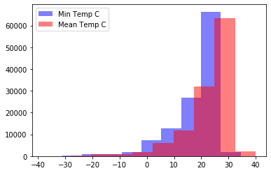

```python
plt.hist(ww2_weath['MinTemp'],
         bins = 10,
         alpha=0.5,
         color='blue',
        label = 'Min Temp C')

plt.hist(ww2_weath['MeanTemp'],
        bins = 10,
        alpha = 0.5,
        color = 'red',
        label = 'Mean Temp C')

plt.legend(loc = 'upper left')

plt.show()
```

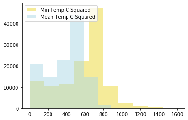

```python
# These are a little left-skewed.  What will happen if we transform them?
ww2_weath['MinTempTransf2'] = ww2_weath[['MinTemp']]**2
ww2_weath['MeanTempTransf2'] = ww2_weath['MeanTemp']**2

plt.hist(ww2_weath['MeanTemp']**2,
         bins = 10,
         alpha=0.5,
         color='#EDD834',
        label = 'Min Temp C Squared')

plt.hist((ww2_weath['MinTemp'])**2,
        bins = 10,
        alpha = 0.5,
        color = 'lightblue',
        label = 'Mean Temp C Squared')


plt.legend(loc = 'upper left')

#plt.show()
```

## We can't check the shape of the other continuous variables because they contain nulls, which the histogram can't handle. We need to decide whether we should impute values for these nulls, or drop the records. Ideally, we do not want to lose data.

```python
# For this exercise, we will use the mean value to impute.  THis is one of the most "naive" imputation methods, unlike other
# methods that we will discuss in future lectures.
from sklearn.preprocessing import Imputer
mean_imputer = Imputer(missing_values='NaN', strategy='mean', axis=0)
```

```python
ww2_weath['WindGustSpd'] = ww2_weath['WindGustSpd'].fillna(ww2_weath['WindGustSpd'].mean())
ww2_weath['Snowfall'] = ww2_weath['Snowfall'].fillna(ww2_weath['Snowfall'].mean())
ww2_weath['DR'] = ww2_weath['DR'].fillna(ww2_weath['DR'].mean())
ww2_weath['SPD'] = ww2_weath['SPD'].fillna(ww2_weath['SPD'].mean())
ww2_weath['MEA'] = ww2_weath['MEA'].fillna(ww2_weath['MEA'].mean())
ww2_weath['MAX'] = ww2_weath['MAX'].fillna(ww2_weath['MAX'].mean())
ww2_weath['MIN'] = ww2_weath['MIN'].fillna(ww2_weath['MIN'].mean())
ww2_weath['SNF'] = ww2_weath['SNF'].fillna(ww2_weath['SNF'].mean())
ww2_weath['SND'] = ww2_weath['SND'].fillna(ww2_weath['SND'].mean())
ww2_weath['PGT'] = ww2_weath['PGT'].fillna(ww2_weath['PGT'].mean())
```

```python
sum(ww2_weath['SND'].isnull())
```

```
0
```

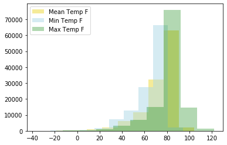

```python
plt.hist(ww2_weath['MEA'],
         bins = 10,
         alpha=0.5,
         color='#EDD834',
        label = 'Mean Temp F')

plt.hist(ww2_weath['MIN'],
        bins = 10,
        alpha = 0.5,
        color = 'lightblue',
        label = 'Min Temp F')

plt.hist(ww2_weath['MAX'],
        bins = 10,
        alpha = 0.3,
        color = 'green',
        label = 'Max Temp F')

plt.legend(loc = 'upper left')

plt.show()
```

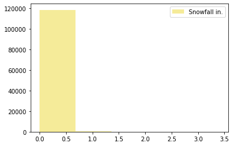

```python
plt.hist(ww2_weath['SNF'],
         bins = 5,
         alpha=0.5,
         color='#EDD834',
        label = 'Snowfall in.')

plt.legend(loc = 'upper right')

plt.show()
```

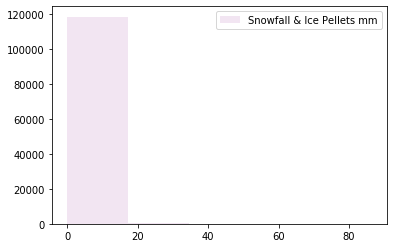

```python
plt.hist(ww2_weath['Snowfall'],
        bins = 5,
        alpha = 0.1,
        color = 'purple',
        label = 'Snowfall & Ice Pellets mm')

plt.legend(loc = 'upper right')

plt.show()
```

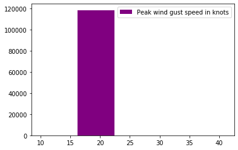

```python
plt.hist(ww2_weath['SPD'],
        bins = 5,
        #alpha = 0.1,
        color = 'purple',
        label = 'Peak wind gust speed in knots')

plt.legend(loc = 'upper right')

plt.show()
```

```python
ww2_weath['SPD'].describe()
```

```
count    118996.000000
mean         20.396617
std           0.371438
min          10.000000
25%          20.396617
50%          20.396617
75%          20.396617
max          41.000000
Name: SPD, dtype: float64
```

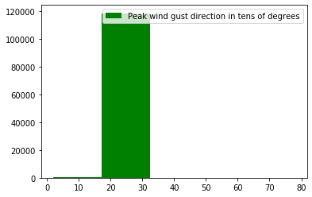

```python
plt.hist(ww2_weath['DR'],
        bins = 5,
        #alpha = 0.1,
        color = 'green',
        label = 'Peak wind gust direction in tens of degrees')

plt.legend(loc = 'upper right')

plt.show()
```

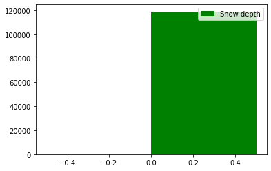

```python
plt.hist(ww2_weath['SND'],
        bins = 2,
        #alpha = 0.1,
        color = 'green',
        label = 'Snow depth')

plt.legend(loc = 'upper right')

plt.show()
```

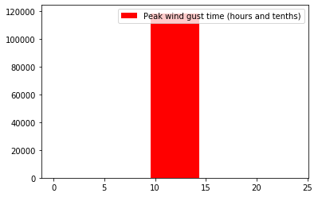

```python
plt.hist(ww2_weath['PGT'],
        bins = 5,
        #alpha = 0.1,
        color = 'red',
        label = 'Peak wind gust time (hours and tenths)')

plt.legend(loc = 'upper right')

plt.show()
```

### We can see that, for the fields with a significant number of null values, imputing the mean value has given the field almost no predictive power, as we will likely see in our predictive model.

# Variable selection and Model creation

### For this exercise, we will seek to predict the max temp by Celsius

```python
ww2_weath.isnull().sum(axis = 0)
```

```
STA                    0
Date                   0
Precip                 0
WindGustSpd            0
MaxTemp                0
MinTemp                0
MeanTemp               0
Snowfall               0
YR                     0
MO                     0
DA                     0
PRCP                1932
DR                     0
SPD                    0
MAX                    0
MIN                    0
MEA                    0
SNF                    0
SND                    0
PGT                    0
TSHDSBRSGF         84770
MinTempTransf2         0
MeanTempTransf2        0
dtype: int64
```

```python
ww2_weath.dtypes
```

```
STA                 object
Date                object
Precip              object
WindGustSpd        float64
MaxTemp            float64
MinTemp            float64
MeanTemp           float64
Snowfall           float64
YR                   int64
MO                   int64
DA                   int64
PRCP                object
DR                 float64
SPD                float64
MAX                float64
MIN                float64
MEA                float64
SNF                float64
SND                float64
PGT                float64
TSHDSBRSGF          object
MinTempTransf2     float64
MeanTempTransf2    float64
dtype: object
```

```python
ww2_weath.head()
```

|  | STA | Date | Precip | WindGustSpd | MaxTemp | MinTemp | MeanTemp | Snowfall | YR | MO | DA | PRCP | DR | SPD | MAX | MIN | MEA | SNF | SND | PGT | TSHDSBRSGF | MinTempTransf2 | MeanTempTransf2 |
| --- | --- | --- | --- | --- | --- | --- | --- | --- | --- | --- | --- | --- | --- | --- | --- | --- | --- | --- | --- | --- | --- | --- | --- |
| 0 | 10001 | 1942-7-1 | 1.016 | 37.774534 | 25.555556 | 22.222222 | 23.888889 | 0.0 | 42 | 7 | 1 | 0.04 | 26.998124 | 20.396617 | 78.0 | 72.0 | 75.0 | 0.0 | 0.0 | 12.085333 | NaN | 493.827160 | 570.679012 |
| 1 | 10001 | 1942-7-2 | 0 | 37.774534 | 28.888889 | 21.666667 | 25.555556 | 0.0 | 42 | 7 | 2 | 0 | 26.998124 | 20.396617 | 84.0 | 71.0 | 78.0 | 0.0 | 0.0 | 12.085333 | NaN | 469.444445 | 653.086420 |
| 2 | 10001 | 1942-7-3 | 2.54 | 37.774534 | 26.111111 | 22.222222 | 24.444444 | 0.0 | 42 | 7 | 3 | 0.1 | 26.998124 | 20.396617 | 79.0 | 72.0 | 76.0 | 0.0 | 0.0 | 12.085333 | NaN | 493.827160 | 597.530864 |
| 3 | 10001 | 1942-7-4 | 2.54 | 37.774534 | 26.666667 | 22.222222 | 24.444444 | 0.0 | 42 | 7 | 4 | 0.1 | 26.998124 | 20.396617 | 80.0 | 72.0 | 76.0 | 0.0 | 0.0 | 12.085333 | NaN | 493.827160 | 597.530864 |
| 4 | 10001 | 1942-7-5 | 0 | 37.774534 | 26.666667 | 21.666667 | 24.444444 | 0.0 | 42 | 7 | 5 | 0 | 26.998124 | 20.396617 | 80.0 | 71.0 | 76.0 | 0.0 | 0.0 | 12.085333 | NaN | 469.444445 | 597.530864 |

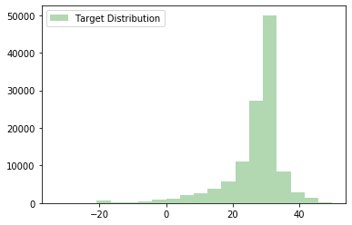

```python
# What about the distribution of our target?
plt.hist(ww2_weath['MaxTemp'],
        bins = 20,
        alpha = 0.3,
        color = 'green',
        label = 'Target Distribution')

plt.legend(loc = 'upper left')

plt.show()
```

### Remaining eligible prediction variables:

- STA (categorical)
- WindGustSpd
- MinTemp
- MeanTemp
- Snowfall
- MO (Categorical)
- DR
- SPD
- MIN
- MEA
- SNF
- SND
- PGT

### Dropping highly correlated features

```python
## First, let's look at highly correlated continuous variables
# Create correlation matrix
import seaborn as sns
ww2_weath_float_vars = ww2_weath[['WindGustSpd', 'MinTemp', 'MeanTemp', 'Snowfall', 'DR', 'SPD', 'MIN', 'MEA', 'SNF', 'SND',
                                 'PGT']]
#ww2_weath_float_vars.head()
corr_matrix = ww2_weath_float_vars.corr().abs()
```

```python
# Generate a mask for the upper triangle
mask = np.zeros_like(corr_matrix, dtype=np.bool)
mask[np.triu_indices_from(mask)] = True
```

```python
# Select the upper part of the triangle
upper = corr_matrix.where(np.triu(np.ones(corr_matrix.shape), k=1).astype(np.bool))
```

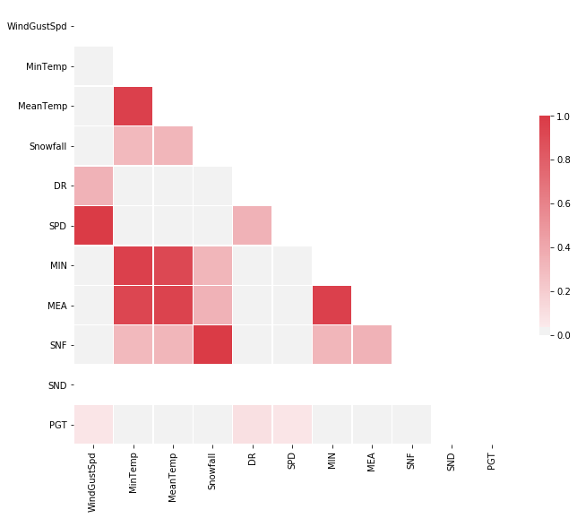

```python
# Set up the matplotlib figure
f, ax = plt.subplots(figsize=(11, 9))

# Generate a custom diverging colormap
cmap = sns.diverging_palette(220, 10, as_cmap=True)

# Draw the heatmap with the mask and correct aspect ratio
sns.heatmap(corr_matrix, mask=mask, cmap=cmap, vmax=1, center=0,
            square=True, linewidths=.5, cbar_kws={"shrink": .5})
```

```python
#We can also look at this in raw form:
corr_matrix

#We can see that the temperatures measured in C and F are highly correlated.  Given that the target is measure in C,
# it is probably wise to not use the F Temperature columns as predictors

# We could, in theory, also check the correlation between the C temp features and F temp features with respect to the target
```

|  | WindGustSpd | MinTemp | MeanTemp | Snowfall | DR | SPD | MIN | MEA | SNF | SND | PGT |
| --- | --- | --- | --- | --- | --- | --- | --- | --- | --- | --- | --- |
| WindGustSpd | 1.000000e+00 | 0.014547 | 0.006029 | 4.335345e-16 | 3.509761e-01 | 1.000000e+00 | 0.015103 | 0.006352 | 7.495710e-16 | NaN | 6.344282e-02 |
| MinTemp | 1.454723e-02 | 1.000000 | 0.965292 | 3.105900e-01 | 2.451488e-02 | 1.454723e-02 | 0.963219 | 0.930892 | 3.105900e-01 | NaN | 3.538512e-04 |
| MeanTemp | 6.029491e-03 | 0.965292 | 1.000000 | 3.266669e-01 | 1.245686e-02 | 6.029491e-03 | 0.917433 | 0.949199 | 3.266669e-01 | NaN | 6.645112e-04 |
| Snowfall | 4.335345e-16 | 0.310590 | 0.326667 | 1.000000e+00 | 1.078717e-15 | 1.080207e-15 | 0.322195 | 0.343977 | 1.000000e+00 | NaN | 1.818996e-16 |
| DR | 3.509761e-01 | 0.024515 | 0.012457 | 1.078717e-15 | 1.000000e+00 | 3.509761e-01 | 0.025451 | 0.013124 | 2.256650e-15 | NaN | 9.835302e-02 |
| SPD | 1.000000e+00 | 0.014547 | 0.006029 | 1.080207e-15 | 3.509761e-01 | 1.000000e+00 | 0.015103 | 0.006352 | 2.969031e-16 | NaN | 6.344282e-02 |
| MIN | 1.510272e-02 | 0.963219 | 0.917433 | 3.221947e-01 | 2.545099e-02 | 1.510272e-02 | 1.000000 | 0.966446 | 3.221947e-01 | NaN | 3.673631e-04 |
| MEA | 6.352188e-03 | 0.930892 | 0.949199 | 3.439775e-01 | 1.312355e-02 | 6.352188e-03 | 0.966446 | 1.000000 | 3.439775e-01 | NaN | 7.000757e-04 |
| SNF | 7.495710e-16 | 0.310590 | 0.326667 | 1.000000e+00 | 2.256650e-15 | 2.969031e-16 | 0.322195 | 0.343977 | 1.000000e+00 | NaN | 1.436903e-16 |
| SND | NaN | NaN | NaN | NaN | NaN | NaN | NaN | NaN | NaN | NaN | NaN |
| PGT | 6.344282e-02 | 0.000354 | 0.000665 | 1.818996e-16 | 9.835302e-02 | 6.344282e-02 | 0.000367 | 0.000700 | 1.436903e-16 | NaN | 1.000000e+00 |